# Risk Factor Analysis

## Outcome Variable

**Outcome Variable:** stunted

## Predictor Variables

**Intervention Variable:** parity

**Adjustment Set:**

unadjusted

## Stratifying Variables

The analysis was stratified on these variable(s):

- agecat
- studyid
- country

## Data Summary

| agecat | studyid | country | A | n | nA | nAY0 | nAY1 |
| --- | --- | --- | --- | --- | --- | --- | --- |
| Birth | ki1000304b-SAS-CompFeed | INDIA | 1 | 70 | 21 | 15 | 6 |
| Birth | ki1000304b-SAS-CompFeed | INDIA | 2 | 70 | 13 | 9 | 4 |
| Birth | ki1000304b-SAS-CompFeed | INDIA | 3+ | 70 | 36 | 29 | 7 |
| Birth | ki1101329-Keneba | GAMBIA | 1 | 1407 | 156 | 140 | 16 |
| Birth | ki1101329-Keneba | GAMBIA | 2 | 1407 | 146 | 138 | 8 |
| Birth | ki1101329-Keneba | GAMBIA | 3+ | 1407 | 1105 | 1054 | 51 |
| Birth | ki1126311-ZVITAMBO | ZIMBABWE | 1 | 13829 | 5972 | 5332 | 640 |
| Birth | ki1126311-ZVITAMBO | ZIMBABWE | 2 | 13829 | 4125 | 3718 | 407 |
| Birth | ki1126311-ZVITAMBO | ZIMBABWE | 3+ | 13829 | 3732 | 3347 | 385 |
| Birth | ki1135781-COHORTS | GUATEMALA | 1 | 407 | 57 | 54 | 3 |
| Birth | ki1135781-COHORTS | GUATEMALA | 2 | 407 | 70 | 66 | 4 |
| Birth | ki1135781-COHORTS | GUATEMALA | 3+ | 407 | 280 | 268 | 12 |
| Birth | ki1135781-COHORTS | INDIA | 1 | 4122 | 696 | 582 | 114 |
| Birth | ki1135781-COHORTS | INDIA | 2 | 4122 | 1037 | 939 | 98 |
| Birth | ki1135781-COHORTS | INDIA | 3+ | 4122 | 2389 | 2126 | 263 |
| Birth | ki1135781-COHORTS | PHILIPPINES | 1 | 3050 | 675 | 629 | 46 |
| Birth | ki1135781-COHORTS | PHILIPPINES | 2 | 3050 | 687 | 645 | 42 |
| Birth | ki1135781-COHORTS | PHILIPPINES | 3+ | 3050 | 1688 | 1589 | 99 |
| Birth | kiGH5241-JiVitA-3 | BANGLADESH | 1 | 9734 | 3136 | 1826 | 1310 |
| Birth | kiGH5241-JiVitA-3 | BANGLADESH | 2 | 9734 | 3351 | 2300 | 1051 |
| Birth | kiGH5241-JiVitA-3 | BANGLADESH | 3+ | 9734 | 3247 | 2285 | 962 |
| 3 months | ki1000304b-SAS-CompFeed | INDIA | 1 | 412 | 114 | 85 | 29 |
| 3 months | ki1000304b-SAS-CompFeed | INDIA | 2 | 412 | 98 | 73 | 25 |
| 3 months | ki1000304b-SAS-CompFeed | INDIA | 3+ | 412 | 200 | 144 | 56 |
| 3 months | ki1000304b-SAS-FoodSuppl | INDIA | 1 | 93 | 17 | 10 | 7 |
| 3 months | ki1000304b-SAS-FoodSuppl | INDIA | 2 | 93 | 19 | 12 | 7 |
| 3 months | ki1000304b-SAS-FoodSuppl | INDIA | 3+ | 93 | 57 | 35 | 22 |
| 3 months | ki1017093b-PROVIDE | BANGLADESH | 1 | 645 | 245 | 207 | 38 |
| 3 months | ki1017093b-PROVIDE | BANGLADESH | 2 | 645 | 227 | 199 | 28 |
| 3 months | ki1017093b-PROVIDE | BANGLADESH | 3+ | 645 | 173 | 161 | 12 |

[output cut: 174 more lines]

The following strata were considered:

- agecat: 12 months, studyid: ki1000304b-SAS-CompFeed, country: INDIA
- agecat: 12 months, studyid: ki1000304b-SAS-FoodSuppl, country: INDIA
- agecat: 12 months, studyid: ki1017093b-PROVIDE, country: BANGLADESH
- agecat: 12 months, studyid: ki1066203-TanzaniaChild2, country: TANZANIA, UNITED REPUBLIC OF
- agecat: 12 months, studyid: ki1101329-Keneba, country: GAMBIA
- agecat: 12 months, studyid: ki1113344-GMS-Nepal, country: NEPAL
- agecat: 12 months, studyid: ki1126311-ZVITAMBO, country: ZIMBABWE
- agecat: 12 months, studyid: ki1135781-COHORTS, country: GUATEMALA
- agecat: 12 months, studyid: ki1135781-COHORTS, country: INDIA
- agecat: 12 months, studyid: ki1135781-COHORTS, country: PHILIPPINES
- agecat: 12 months, studyid: kiGH5241-JiVitA-3, country: BANGLADESH
- agecat: 18 months, studyid: ki1000304b-SAS-CompFeed, country: INDIA
- agecat: 18 months, studyid: ki1000304b-SAS-FoodSuppl, country: INDIA
- agecat: 18 months, studyid: ki1017093b-PROVIDE, country: BANGLADESH
- agecat: 18 months, studyid: ki1066203-TanzaniaChild2, country: TANZANIA, UNITED REPUBLIC OF
- agecat: 18 months, studyid: ki1101329-Keneba, country: GAMBIA
- agecat: 18 months, studyid: ki1113344-GMS-Nepal, country: NEPAL
- agecat: 18 months, studyid: ki1126311-ZVITAMBO, country: ZIMBABWE
- agecat: 18 months, studyid: ki1135781-COHORTS, country: GUATEMALA
- agecat: 18 months, studyid: ki1135781-COHORTS, country: PHILIPPINES
- agecat: 24 months, studyid: ki1017093b-PROVIDE, country: BANGLADESH
- agecat: 24 months, studyid: ki1066203-TanzaniaChild2, country: TANZANIA, UNITED REPUBLIC OF
- agecat: 24 months, studyid: ki1101329-Keneba, country: GAMBIA
- agecat: 24 months, studyid: ki1113344-GMS-Nepal, country: NEPAL
- agecat: 24 months, studyid: ki1126311-ZVITAMBO, country: ZIMBABWE
- agecat: 24 months, studyid: ki1135781-COHORTS, country: GUATEMALA
- agecat: 24 months, studyid: ki1135781-COHORTS, country: INDIA
- agecat: 24 months, studyid: ki1135781-COHORTS, country: PHILIPPINES
- agecat: 24 months, studyid: kiGH5241-JiVitA-3, country: BANGLADESH
- agecat: 3 months, studyid: ki1000304b-SAS-CompFeed, country: INDIA
- agecat: 3 months, studyid: ki1000304b-SAS-FoodSuppl, country: INDIA
- agecat: 3 months, studyid: ki1017093b-PROVIDE, country: BANGLADESH
- agecat: 3 months, studyid: ki1066203-TanzaniaChild2, country: TANZANIA, UNITED REPUBLIC OF
- agecat: 3 months, studyid: ki1101329-Keneba, country: GAMBIA
- agecat: 3 months, studyid: ki1113344-GMS-Nepal, country: NEPAL
- agecat: 3 months, studyid: ki1126311-ZVITAMBO, country: ZIMBABWE
- agecat: 3 months, studyid: ki1135781-COHORTS, country: GUATEMALA
- agecat: 3 months, studyid: ki1135781-COHORTS, country: INDIA
- agecat: 3 months, studyid: ki1135781-COHORTS, country: PHILIPPINES
- agecat: 3 months, studyid: kiGH5241-JiVitA-3, country: BANGLADESH
- agecat: 6 months, studyid: ki1000304b-SAS-CompFeed, country: INDIA
- agecat: 6 months, studyid: ki1000304b-SAS-FoodSuppl, country: INDIA
- agecat: 6 months, studyid: ki1017093b-PROVIDE, country: BANGLADESH
- agecat: 6 months, studyid: ki1066203-TanzaniaChild2, country: TANZANIA, UNITED REPUBLIC OF
- agecat: 6 months, studyid: ki1101329-Keneba, country: GAMBIA
- agecat: 6 months, studyid: ki1113344-GMS-Nepal, country: NEPAL
- agecat: 6 months, studyid: ki1126311-ZVITAMBO, country: ZIMBABWE
- agecat: 6 months, studyid: ki1135781-COHORTS, country: GUATEMALA
- agecat: 6 months, studyid: ki1135781-COHORTS, country: INDIA
- agecat: 6 months, studyid: ki1135781-COHORTS, country: PHILIPPINES
- agecat: 6 months, studyid: kiGH5241-JiVitA-3, country: BANGLADESH
- agecat: 9 months, studyid: ki1000304b-SAS-CompFeed, country: INDIA
- agecat: 9 months, studyid: ki1000304b-SAS-FoodSuppl, country: INDIA
- agecat: 9 months, studyid: ki1017093b-PROVIDE, country: BANGLADESH
- agecat: 9 months, studyid: ki1066203-TanzaniaChild2, country: TANZANIA, UNITED REPUBLIC OF
- agecat: 9 months, studyid: ki1101329-Keneba, country: GAMBIA
- agecat: 9 months, studyid: ki1113344-GMS-Nepal, country: NEPAL
- agecat: 9 months, studyid: ki1126311-ZVITAMBO, country: ZIMBABWE
- agecat: 9 months, studyid: ki1135781-COHORTS, country: GUATEMALA
- agecat: 9 months, studyid: ki1135781-COHORTS, country: INDIA
- agecat: 9 months, studyid: ki1135781-COHORTS, country: PHILIPPINES
- agecat: Birth, studyid: ki1000304b-SAS-CompFeed, country: INDIA
- agecat: Birth, studyid: ki1101329-Keneba, country: GAMBIA
- agecat: Birth, studyid: ki1126311-ZVITAMBO, country: ZIMBABWE
- agecat: Birth, studyid: ki1135781-COHORTS, country: GUATEMALA
- agecat: Birth, studyid: ki1135781-COHORTS, country: INDIA
- agecat: Birth, studyid: ki1135781-COHORTS, country: PHILIPPINES
- agecat: Birth, studyid: kiGH5241-JiVitA-3, country: BANGLADESH

### Dropped Strata

Some strata were dropped due to rare outcomes:

- agecat: Birth, studyid: ki1000304b-SAS-CompFeed, country: INDIA
- agecat: Birth, studyid: ki1135781-COHORTS, country: GUATEMALA
- agecat: 12 months, studyid: ki1000304b-SAS-FoodSuppl, country: INDIA
- agecat: 18 months, studyid: ki1000304b-SAS-FoodSuppl, country: INDIA
- agecat: 24 months, studyid: ki1066203-TanzaniaChild2, country: TANZANIA, UNITED REPUBLIC OF

## Methods Detail

We’re interested in the causal parameters $E[Y_a]$ for all values of $a \in \mathcal{A}$. These parameters represent the mean outcome if, possibly contrary to fact, we intervened to set all units to have $A=a$. Under the randomization and positivity assumptions, these are identified by the statistical parameters $\psi_a=E_W[E_{Y|A,W}(Y|A=a,W)]$. In addition, we’re interested in the mean of $Y$, $E[Y]$ under no intervention (the observed mean). We will estimate these parameters by using SuperLearner to fit the relevant likelihood factors – $E_{Y|A,W}(Y|A=a,W)$ and $p(A=a|W)$, and then updating our likelihood fit using a joint TMLE.

For unadjusted analyses ($W=\{\}$), initial likelihoods were estimated using Lrnr_glm to estimate the simple $E(Y|A)$ and Lrnr_mean to estimate $p(A)$. For adjusted analyses, a small library containing Lrnr_glmnet, Lrnr_xgboost, and Lrnr_mean was used.

Having estimated these parameters, we will then use the delta method to estimate relative risks and attributable risks relative to a prespecified baseline level of $A$.

# Results Detail

## Results Plots

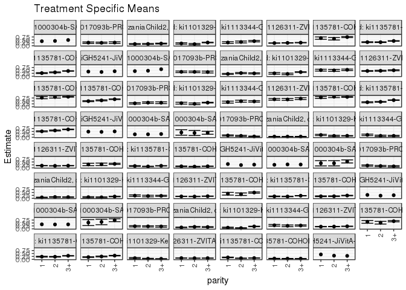

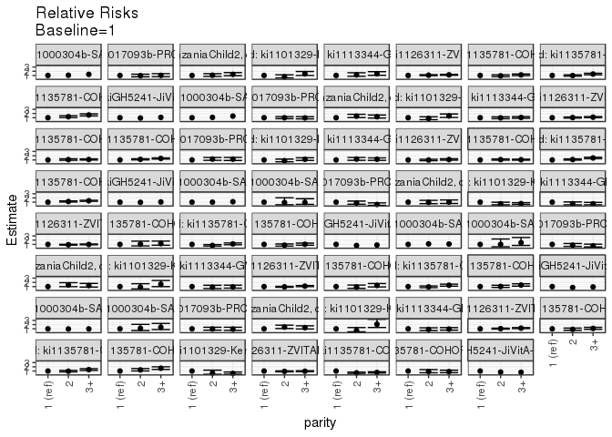

[figure not shown]

[figure not shown]

## Results Table

### Parameter: TSM

| agecat | studyid | country | intervention_level | baseline_level | estimate | ci_lower | ci_upper |
| --- | --- | --- | --- | --- | --- | --- | --- |
| Birth | ki1101329-Keneba | GAMBIA | 1 | NA | 0.1025641 | 0.0549386 | 0.1501896 |
| Birth | ki1101329-Keneba | GAMBIA | 2 | NA | 0.0547945 | 0.0178664 | 0.0917227 |
| Birth | ki1101329-Keneba | GAMBIA | 3+ | NA | 0.0461538 | 0.0337783 | 0.0585294 |
| Birth | ki1126311-ZVITAMBO | ZIMBABWE | 1 | NA | 0.1071668 | 0.0993213 | 0.1150123 |
| Birth | ki1126311-ZVITAMBO | ZIMBABWE | 2 | NA | 0.0986667 | 0.0895659 | 0.1077675 |
| Birth | ki1126311-ZVITAMBO | ZIMBABWE | 3+ | NA | 0.1031618 | 0.0934027 | 0.1129209 |
| Birth | ki1135781-COHORTS | INDIA | 1 | NA | 0.1637931 | 0.1362951 | 0.1912911 |
| Birth | ki1135781-COHORTS | INDIA | 2 | NA | 0.0945034 | 0.0766969 | 0.1123099 |
| Birth | ki1135781-COHORTS | INDIA | 3+ | NA | 0.1100879 | 0.0975352 | 0.1226406 |
| Birth | ki1135781-COHORTS | PHILIPPINES | 1 | NA | 0.0681481 | 0.0491344 | 0.0871619 |
| Birth | ki1135781-COHORTS | PHILIPPINES | 2 | NA | 0.0611354 | 0.0432174 | 0.0790533 |
| Birth | ki1135781-COHORTS | PHILIPPINES | 3+ | NA | 0.0586493 | 0.0474384 | 0.0698602 |
| Birth | kiGH5241-JiVitA-3 | BANGLADESH | 1 | NA | 0.4177296 | NA | NA |
| Birth | kiGH5241-JiVitA-3 | BANGLADESH | 2 | NA | 0.3136377 | NA | NA |
| Birth | kiGH5241-JiVitA-3 | BANGLADESH | 3+ | NA | 0.2962735 | NA | NA |
| 3 months | ki1000304b-SAS-CompFeed | INDIA | 1 | NA | 0.2543860 | NA | NA |
| 3 months | ki1000304b-SAS-CompFeed | INDIA | 2 | NA | 0.2551020 | NA | NA |
| 3 months | ki1000304b-SAS-CompFeed | INDIA | 3+ | NA | 0.2800000 | NA | NA |
| 3 months | ki1000304b-SAS-FoodSuppl | INDIA | 1 | NA | 0.4117647 | 0.1765463 | 0.6469831 |
| 3 months | ki1000304b-SAS-FoodSuppl | INDIA | 2 | NA | 0.3684211 | 0.1503465 | 0.5864956 |
| 3 months | ki1000304b-SAS-FoodSuppl | INDIA | 3+ | NA | 0.3859649 | 0.2588991 | 0.5130307 |
| 3 months | ki1017093b-PROVIDE | BANGLADESH | 1 | NA | 0.1551020 | 0.1097379 | 0.2004662 |
| 3 months | ki1017093b-PROVIDE | BANGLADESH | 2 | NA | 0.1233480 | 0.0805374 | 0.1661587 |
| 3 months | ki1017093b-PROVIDE | BANGLADESH | 3+ | NA | 0.0693642 | 0.0314746 | 0.1072537 |
| 3 months | ki1066203-TanzaniaChild2 | TANZANIA, UNITED REPUBLIC OF | 1 | NA | 0.0592686 | 0.0428305 | 0.0757067 |
| 3 months | ki1066203-TanzaniaChild2 | TANZANIA, UNITED REPUBLIC OF | 2 | NA | 0.0567568 | 0.0400824 | 0.0734311 |
| 3 months | ki1066203-TanzaniaChild2 | TANZANIA, UNITED REPUBLIC OF | 3+ | NA | 0.0602740 | 0.0430057 | 0.0775422 |
| 3 months | ki1101329-Keneba | GAMBIA | 1 | NA | 0.1981132 | 0.1444444 | 0.2517820 |
| 3 months | ki1101329-Keneba | GAMBIA | 2 | NA | 0.1208791 | 0.0735050 | 0.1682532 |
| 3 months | ki1101329-Keneba | GAMBIA | 3+ | NA | 0.1274131 | 0.1092474 | 0.1455789 |

[output cut: 159 more lines]

### Parameter: E(Y)

| agecat | studyid | country | intervention_level | baseline_level | estimate | ci_lower | ci_upper |
| --- | --- | --- | --- | --- | --- | --- | --- |
| Birth | ki1101329-Keneba | GAMBIA | NA | NA | 0.0533049 | 0.0415629 | 0.0650470 |
| Birth | ki1126311-ZVITAMBO | ZIMBABWE | NA | NA | 0.1035505 | 0.0984723 | 0.1086287 |
| Birth | ki1135781-COHORTS | INDIA | NA | NA | 0.1152353 | 0.1054865 | 0.1249842 |
| Birth | ki1135781-COHORTS | PHILIPPINES | NA | NA | 0.0613115 | 0.0527962 | 0.0698268 |
| Birth | kiGH5241-JiVitA-3 | BANGLADESH | NA | NA | 0.3413807 | NA | NA |
| 3 months | ki1000304b-SAS-CompFeed | INDIA | NA | NA | 0.2669903 | NA | NA |
| 3 months | ki1000304b-SAS-FoodSuppl | INDIA | NA | NA | 0.3870968 | 0.2875654 | 0.4866281 |
| 3 months | ki1017093b-PROVIDE | BANGLADESH | NA | NA | 0.1209302 | 0.0957486 | 0.1461119 |
| 3 months | ki1066203-TanzaniaChild2 | TANZANIA, UNITED REPUBLIC OF | NA | NA | 0.0587715 | 0.0490791 | 0.0684640 |
| 3 months | ki1101329-Keneba | GAMBIA | NA | NA | 0.1355832 | 0.1192517 | 0.1519147 |
| 3 months | ki1113344-GMS-Nepal | NEPAL | NA | NA | 0.1471103 | 0.1180314 | 0.1761893 |
| 3 months | ki1126311-ZVITAMBO | ZIMBABWE | NA | NA | 0.1780896 | 0.1702680 | 0.1859113 |
| 3 months | ki1135781-COHORTS | GUATEMALA | NA | NA | 0.3206751 | 0.2786132 | 0.3627370 |
| 3 months | ki1135781-COHORTS | INDIA | NA | NA | 0.1537054 | 0.1430133 | 0.1643975 |
| 3 months | ki1135781-COHORTS | PHILIPPINES | NA | NA | 0.1234783 | 0.1114506 | 0.1355059 |
| 3 months | kiGH5241-JiVitA-3 | BANGLADESH | NA | NA | 0.2768242 | NA | NA |
| 6 months | ki1000304b-SAS-CompFeed | INDIA | NA | NA | 0.2749392 | NA | NA |
| 6 months | ki1000304b-SAS-FoodSuppl | INDIA | NA | NA | 0.4838710 | 0.3817540 | 0.5859880 |
| 6 months | ki1017093b-PROVIDE | BANGLADESH | NA | NA | 0.1612350 | 0.1313580 | 0.1911120 |
| 6 months | ki1066203-TanzaniaChild2 | TANZANIA, UNITED REPUBLIC OF | NA | NA | 0.0965000 | 0.0835560 | 0.1094440 |
| 6 months | ki1101329-Keneba | GAMBIA | NA | NA | 0.1398645 | 0.1229849 | 0.1567440 |
| 6 months | ki1113344-GMS-Nepal | NEPAL | NA | NA | 0.2113677 | 0.1776128 | 0.2451225 |
| 6 months | ki1126311-ZVITAMBO | ZIMBABWE | NA | NA | 0.1662648 | 0.1582516 | 0.1742780 |
| 6 months | ki1135781-COHORTS | GUATEMALA | NA | NA | 0.4547414 | 0.4093847 | 0.5000980 |
| 6 months | ki1135781-COHORTS | INDIA | NA | NA | 0.1957586 | 0.1838852 | 0.2076319 |
| 6 months | ki1135781-COHORTS | PHILIPPINES | NA | NA | 0.2112260 | 0.1958496 | 0.2266024 |
| 6 months | kiGH5241-JiVitA-3 | BANGLADESH | NA | NA | 0.2617272 | NA | NA |
| 9 months | ki1000304b-SAS-CompFeed | INDIA | NA | NA | 0.3787129 | NA | NA |
| 9 months | ki1000304b-SAS-FoodSuppl | INDIA | NA | NA | 0.6705882 | 0.5700790 | 0.7710975 |
| 9 months | ki1017093b-PROVIDE | BANGLADESH | NA | NA | 0.2132231 | 0.1805589 | 0.2458874 |
| 9 months | ki1066203-TanzaniaChild2 | TANZANIA, UNITED REPUBLIC OF | NA | NA | 0.1479592 | 0.1313853 | 0.1645330 |
| 9 months | ki1101329-Keneba | GAMBIA | NA | NA | 0.1790769 | 0.1604292 | 0.1977247 |
| 9 months | ki1113344-GMS-Nepal | NEPAL | NA | NA | 0.2813067 | 0.2437292 | 0.3188843 |
| 9 months | ki1126311-ZVITAMBO | ZIMBABWE | NA | NA | 0.1979411 | 0.1890258 | 0.2068564 |
| 9 months | ki1135781-COHORTS | GUATEMALA | NA | NA | 0.6225166 | 0.5778273 | 0.6672058 |
| 9 months | ki1135781-COHORTS | INDIA | NA | NA | 0.2711595 | 0.2569649 | 0.2853540 |
| 9 months | ki1135781-COHORTS | PHILIPPINES | NA | NA | 0.2750737 | 0.2582642 | 0.2918832 |
| 12 months | ki1000304b-SAS-CompFeed | INDIA | NA | NA | 0.4420290 | NA | NA |
| 12 months | ki1017093b-PROVIDE | BANGLADESH | NA | NA | 0.2616667 | 0.2264673 | 0.2968661 |
| 12 months | ki1066203-TanzaniaChild2 | TANZANIA, UNITED REPUBLIC OF | NA | NA | 0.1638537 | 0.1446086 | 0.1830988 |
| 12 months | ki1101329-Keneba | GAMBIA | NA | NA | 0.2516340 | 0.2298826 | 0.2733853 |
| 12 months | ki1113344-GMS-Nepal | NEPAL | NA | NA | 0.3422939 | 0.3028903 | 0.3816975 |
| 12 months | ki1126311-ZVITAMBO | ZIMBABWE | NA | NA | 0.2445169 | 0.2342613 | 0.2547725 |
| 12 months | ki1135781-COHORTS | GUATEMALA | NA | NA | 0.7035647 | 0.6647578 | 0.7423717 |
| 12 months | ki1135781-COHORTS | INDIA | NA | NA | 0.3648609 | 0.3487131 | 0.3810087 |
| 12 months | ki1135781-COHORTS | PHILIPPINES | NA | NA | 0.3868472 | 0.3680689 | 0.4056255 |
| 12 months | kiGH5241-JiVitA-3 | BANGLADESH | NA | NA | 0.3963626 | NA | NA |
| 18 months | ki1000304b-SAS-CompFeed | INDIA | NA | NA | 0.5240506 | NA | NA |
| 18 months | ki1017093b-PROVIDE | BANGLADESH | NA | NA | 0.3731884 | 0.3328048 | 0.4135720 |
| 18 months | ki1066203-TanzaniaChild2 | TANZANIA, UNITED REPUBLIC OF | NA | NA | 0.2401656 | 0.2132131 | 0.2671181 |
| 18 months | ki1101329-Keneba | GAMBIA | NA | NA | 0.3313878 | 0.3078860 | 0.3548897 |
| 18 months | ki1113344-GMS-Nepal | NEPAL | NA | NA | 0.5309091 | 0.4891645 | 0.5726537 |
| 18 months | ki1126311-ZVITAMBO | ZIMBABWE | NA | NA | 0.4757168 | 0.4520324 | 0.4994011 |
| 18 months | ki1135781-COHORTS | GUATEMALA | NA | NA | 0.8394495 | 0.8049505 | 0.8739485 |
| 18 months | ki1135781-COHORTS | PHILIPPINES | NA | NA | 0.5874799 | 0.5681478 | 0.6068121 |
| 24 months | ki1017093b-PROVIDE | BANGLADESH | NA | NA | 0.3292894 | 0.2909105 | 0.3676684 |
| 24 months | ki1101329-Keneba | GAMBIA | NA | NA | 0.3386628 | 0.3136483 | 0.3636773 |
| 24 months | ki1113344-GMS-Nepal | NEPAL | NA | NA | 0.4468938 | 0.4032281 | 0.4905594 |
| 24 months | ki1126311-ZVITAMBO | ZIMBABWE | NA | NA | 0.6535088 | 0.6097853 | 0.6972322 |
| 24 months | ki1135781-COHORTS | GUATEMALA | NA | NA | 0.8359073 | 0.8039827 | 0.8678320 |
| 24 months | ki1135781-COHORTS | INDIA | NA | NA | 0.5001478 | 0.4832966 | 0.5169990 |
| 24 months | ki1135781-COHORTS | PHILIPPINES | NA | NA | 0.6167689 | 0.5974942 | 0.6360437 |
| 24 months | kiGH5241-JiVitA-3 | BANGLADESH | NA | NA | 0.4815765 | NA | NA |

### Parameter: RR

| agecat | studyid | country | intervention_level | baseline_level | estimate | ci_lower | ci_upper |
| --- | --- | --- | --- | --- | --- | --- | --- |
| Birth | ki1101329-Keneba | GAMBIA | 1 | 1 | 1.0000000 | 1.0000000 | 1.0000000 |
| Birth | ki1101329-Keneba | GAMBIA | 2 | 1 | 0.5342466 | 0.2356709 | 1.2110933 |
| Birth | ki1101329-Keneba | GAMBIA | 3+ | 1 | 0.4500000 | 0.2632335 | 0.7692791 |
| Birth | ki1126311-ZVITAMBO | ZIMBABWE | 1 | 1 | 1.0000000 | 1.0000000 | 1.0000000 |
| Birth | ki1126311-ZVITAMBO | ZIMBABWE | 2 | 1 | 0.9206833 | 0.8184046 | 1.0357442 |
| Birth | ki1126311-ZVITAMBO | ZIMBABWE | 3+ | 1 | 0.9626290 | 0.8541012 | 1.0849470 |
| Birth | ki1135781-COHORTS | INDIA | 1 | 1 | 1.0000000 | 1.0000000 | 1.0000000 |
| Birth | ki1135781-COHORTS | INDIA | 2 | 1 | 0.5769680 | 0.4482824 | 0.7425945 |
| Birth | ki1135781-COHORTS | INDIA | 3+ | 1 | 0.6721156 | 0.5486645 | 0.8233437 |
| Birth | ki1135781-COHORTS | PHILIPPINES | 1 | 1 | 1.0000000 | 1.0000000 | 1.0000000 |
| Birth | ki1135781-COHORTS | PHILIPPINES | 2 | 1 | 0.8970951 | 0.5985491 | 1.3445507 |
| Birth | ki1135781-COHORTS | PHILIPPINES | 3+ | 1 | 0.8606146 | 0.6136598 | 1.2069511 |
| Birth | kiGH5241-JiVitA-3 | BANGLADESH | 1 | 1 | 1.0000000 | NA | NA |
| Birth | kiGH5241-JiVitA-3 | BANGLADESH | 2 | 1 | 0.7508152 | NA | NA |
| Birth | kiGH5241-JiVitA-3 | BANGLADESH | 3+ | 1 | 0.7092471 | NA | NA |
| 3 months | ki1000304b-SAS-CompFeed | INDIA | 1 | 1 | 1.0000000 | NA | NA |
| 3 months | ki1000304b-SAS-CompFeed | INDIA | 2 | 1 | 1.0028149 | NA | NA |
| 3 months | ki1000304b-SAS-CompFeed | INDIA | 3+ | 1 | 1.1006897 | NA | NA |
| 3 months | ki1000304b-SAS-FoodSuppl | INDIA | 1 | 1 | 1.0000000 | 1.0000000 | 1.0000000 |
| 3 months | ki1000304b-SAS-FoodSuppl | INDIA | 2 | 1 | 0.8947368 | 0.3930436 | 2.0368071 |
| 3 months | ki1000304b-SAS-FoodSuppl | INDIA | 3+ | 1 | 0.9373434 | 0.4847964 | 1.8123330 |
| 3 months | ki1017093b-PROVIDE | BANGLADESH | 1 | 1 | 1.0000000 | 1.0000000 | 1.0000000 |
| 3 months | ki1017093b-PROVIDE | BANGLADESH | 2 | 1 | 0.7952701 | 0.5051251 | 1.2520752 |
| 3 months | ki1017093b-PROVIDE | BANGLADESH | 3+ | 1 | 0.4472163 | 0.2406700 | 0.8310234 |
| 3 months | ki1066203-TanzaniaChild2 | TANZANIA, UNITED REPUBLIC OF | 1 | 1 | 1.0000000 | 1.0000000 | 1.0000000 |
| 3 months | ki1066203-TanzaniaChild2 | TANZANIA, UNITED REPUBLIC OF | 2 | 1 | 0.9576193 | 0.6393353 | 1.4343566 |
| 3 months | ki1066203-TanzaniaChild2 | TANZANIA, UNITED REPUBLIC OF | 3+ | 1 | 1.0169630 | 0.6825422 | 1.5152377 |
| 3 months | ki1101329-Keneba | GAMBIA | 1 | 1 | 1.0000000 | 1.0000000 | 1.0000000 |
| 3 months | ki1101329-Keneba | GAMBIA | 2 | 1 | 0.6101518 | 0.3789033 | 0.9825335 |
| 3 months | ki1101329-Keneba | GAMBIA | 3+ | 1 | 0.6431329 | 0.4735342 | 0.8734743 |

[output cut: 159 more lines]

### Parameter: PAR

| agecat | studyid | country | intervention_level | baseline_level | estimate | ci_lower | ci_upper |
| --- | --- | --- | --- | --- | --- | --- | --- |
| Birth | ki1101329-Keneba | GAMBIA | 1 | NA | -0.0492592 | -0.0928837 | -0.0056347 |
| Birth | ki1126311-ZVITAMBO | ZIMBABWE | 1 | NA | -0.0036163 | -0.0094624 | 0.0022299 |
| Birth | ki1135781-COHORTS | INDIA | 1 | NA | -0.0485578 | -0.0729674 | -0.0241481 |
| Birth | ki1135781-COHORTS | PHILIPPINES | 1 | NA | -0.0068367 | -0.0233901 | 0.0097167 |
| Birth | kiGH5241-JiVitA-3 | BANGLADESH | 1 | NA | -0.0763489 | NA | NA |
| 3 months | ki1000304b-SAS-CompFeed | INDIA | 1 | NA | 0.0126043 | NA | NA |
| 3 months | ki1000304b-SAS-FoodSuppl | INDIA | 1 | NA | -0.0246679 | -0.2368161 | 0.1874803 |
| 3 months | ki1017093b-PROVIDE | BANGLADESH | 1 | NA | -0.0341718 | -0.0677672 | -0.0005764 |
| 3 months | ki1066203-TanzaniaChild2 | TANZANIA, UNITED REPUBLIC OF | 1 | NA | -0.0004971 | -0.0137175 | 0.0127234 |
| 3 months | ki1101329-Keneba | GAMBIA | 1 | NA | -0.0625300 | -0.1117641 | -0.0132960 |
| 3 months | ki1113344-GMS-Nepal | NEPAL | 1 | NA | -0.0580179 | -0.1096897 | -0.0063460 |
| 3 months | ki1126311-ZVITAMBO | ZIMBABWE | 1 | NA | -0.0051664 | -0.0148036 | 0.0044707 |
| 3 months | ki1135781-COHORTS | GUATEMALA | 1 | NA | 0.0389850 | -0.0582436 | 0.1362135 |
| 3 months | ki1135781-COHORTS | INDIA | 1 | NA | -0.0003487 | -0.0240537 | 0.0233564 |
| 3 months | ki1135781-COHORTS | PHILIPPINES | 1 | NA | -0.0035576 | -0.0268444 | 0.0197292 |
| 3 months | kiGH5241-JiVitA-3 | BANGLADESH | 1 | NA | -0.0441255 | NA | NA |
| 6 months | ki1000304b-SAS-CompFeed | INDIA | 1 | NA | 0.0168747 | NA | NA |
| 6 months | ki1000304b-SAS-FoodSuppl | INDIA | 1 | NA | 0.0949821 | -0.1095944 | 0.2995585 |
| 6 months | ki1017093b-PROVIDE | BANGLADESH | 1 | NA | -0.0330778 | -0.0740790 | 0.0079234 |
| 6 months | ki1066203-TanzaniaChild2 | TANZANIA, UNITED REPUBLIC OF | 1 | NA | 0.0165000 | -0.0004935 | 0.0334935 |
| 6 months | ki1101329-Keneba | GAMBIA | 1 | NA | 0.0419263 | 0.0017156 | 0.0821370 |
| 6 months | ki1113344-GMS-Nepal | NEPAL | 1 | NA | -0.0173905 | -0.0736494 | 0.0388684 |
| 6 months | ki1126311-ZVITAMBO | ZIMBABWE | 1 | NA | 0.0024247 | -0.0074085 | 0.0122578 |
| 6 months | ki1135781-COHORTS | GUATEMALA | 1 | NA | 0.0634370 | -0.0433058 | 0.1701799 |
| 6 months | ki1135781-COHORTS | INDIA | 1 | NA | 0.0281910 | 0.0033828 | 0.0529991 |
| 6 months | ki1135781-COHORTS | PHILIPPINES | 1 | NA | 0.0370100 | 0.0088802 | 0.0651397 |
| 6 months | kiGH5241-JiVitA-3 | BANGLADESH | 1 | NA | -0.0285653 | NA | NA |
| 9 months | ki1000304b-SAS-CompFeed | INDIA | 1 | NA | -0.0059025 | NA | NA |
| 9 months | ki1000304b-SAS-FoodSuppl | INDIA | 1 | NA | 0.1372549 | -0.0904213 | 0.3649311 |
| 9 months | ki1017093b-PROVIDE | BANGLADESH | 1 | NA | -0.0074976 | -0.0506289 | 0.0356337 |
| 9 months | ki1066203-TanzaniaChild2 | TANZANIA, UNITED REPUBLIC OF | 1 | NA | 0.0269914 | 0.0053001 | 0.0486827 |
| 9 months | ki1101329-Keneba | GAMBIA | 1 | NA | 0.0801758 | 0.0376514 | 0.1227002 |
| 9 months | ki1113344-GMS-Nepal | NEPAL | 1 | NA | -0.0193469 | -0.0806958 | 0.0420021 |
| 9 months | ki1126311-ZVITAMBO | ZIMBABWE | 1 | NA | 0.0110774 | 0.0001662 | 0.0219886 |
| 9 months | ki1135781-COHORTS | GUATEMALA | 1 | NA | 0.0283137 | -0.0782347 | 0.1348620 |
| 9 months | ki1135781-COHORTS | INDIA | 1 | NA | 0.0420573 | 0.0121927 | 0.0719218 |
| 9 months | ki1135781-COHORTS | PHILIPPINES | 1 | NA | 0.0836944 | 0.0542100 | 0.1131789 |
| 12 months | ki1000304b-SAS-CompFeed | INDIA | 1 | NA | 0.0531401 | NA | NA |
| 12 months | ki1017093b-PROVIDE | BANGLADESH | 1 | NA | -0.0031735 | -0.0496777 | 0.0433307 |
| 12 months | ki1066203-TanzaniaChild2 | TANZANIA, UNITED REPUBLIC OF | 1 | NA | 0.0153389 | -0.0101421 | 0.0408198 |
| 12 months | ki1101329-Keneba | GAMBIA | 1 | NA | 0.0565120 | -0.0014969 | 0.1145210 |
| 12 months | ki1113344-GMS-Nepal | NEPAL | 1 | NA | 0.0648746 | 0.0035179 | 0.1262312 |
| 12 months | ki1126311-ZVITAMBO | ZIMBABWE | 1 | NA | 0.0154287 | 0.0027901 | 0.0280673 |
| 12 months | ki1135781-COHORTS | GUATEMALA | 1 | NA | 0.0518793 | -0.0378079 | 0.1415665 |
| 12 months | ki1135781-COHORTS | INDIA | 1 | NA | 0.0583541 | 0.0239884 | 0.0927198 |
| 12 months | ki1135781-COHORTS | PHILIPPINES | 1 | NA | 0.1142840 | 0.0805428 | 0.1480252 |
| 12 months | kiGH5241-JiVitA-3 | BANGLADESH | 1 | NA | -0.0030478 | NA | NA |
| 18 months | ki1000304b-SAS-CompFeed | INDIA | 1 | NA | 0.0860341 | NA | NA |
| 18 months | ki1017093b-PROVIDE | BANGLADESH | 1 | NA | -0.0061219 | -0.0591441 | 0.0469002 |
| 18 months | ki1066203-TanzaniaChild2 | TANZANIA, UNITED REPUBLIC OF | 1 | NA | 0.0389644 | 0.0028698 | 0.0750591 |
| 18 months | ki1101329-Keneba | GAMBIA | 1 | NA | 0.0797749 | 0.0143273 | 0.1452225 |
| 18 months | ki1113344-GMS-Nepal | NEPAL | 1 | NA | 0.0083284 | -0.0583475 | 0.0750044 |
| 18 months | ki1126311-ZVITAMBO | ZIMBABWE | 1 | NA | 0.0225918 | -0.0079784 | 0.0531620 |
| 18 months | ki1135781-COHORTS | GUATEMALA | 1 | NA | 0.0602288 | -0.0219548 | 0.1424123 |
| 18 months | ki1135781-COHORTS | PHILIPPINES | 1 | NA | 0.1073287 | 0.0696832 | 0.1449742 |
| 24 months | ki1017093b-PROVIDE | BANGLADESH | 1 | NA | 0.0354506 | -0.0144444 | 0.0853456 |
| 24 months | ki1101329-Keneba | GAMBIA | 1 | NA | 0.0320934 | -0.0414121 | 0.1055990 |
| 24 months | ki1113344-GMS-Nepal | NEPAL | 1 | NA | 0.0498350 | -0.0207982 | 0.1204682 |
| 24 months | ki1126311-ZVITAMBO | ZIMBABWE | 1 | NA | 0.0150907 | -0.0399988 | 0.0701802 |
| 24 months | ki1135781-COHORTS | GUATEMALA | 1 | NA | 0.0359073 | -0.0356736 | 0.1074883 |
| 24 months | ki1135781-COHORTS | INDIA | 1 | NA | 0.1143071 | 0.0774659 | 0.1511483 |
| 24 months | ki1135781-COHORTS | PHILIPPINES | 1 | NA | 0.1091353 | 0.0714673 | 0.1468034 |
| 24 months | kiGH5241-JiVitA-3 | BANGLADESH | 1 | NA | -0.0012253 | NA | NA |

### Parameter: PAF

| agecat | studyid | country | intervention_level | baseline_level | estimate | ci_lower | ci_upper |
| --- | --- | --- | --- | --- | --- | --- | --- |
| Birth | ki1101329-Keneba | GAMBIA | 1 | NA | -0.9241025 | -1.9135260 | -0.2706839 |
| Birth | ki1126311-ZVITAMBO | ZIMBABWE | 1 | NA | -0.0349227 | -0.0929274 | 0.0200035 |
| Birth | ki1135781-COHORTS | INDIA | 1 | NA | -0.4213793 | -0.6476006 | -0.2262190 |
| Birth | ki1135781-COHORTS | PHILIPPINES | 1 | NA | -0.1115072 | -0.4166265 | 0.1278941 |
| Birth | kiGH5241-JiVitA-3 | BANGLADESH | 1 | NA | -0.2236473 | NA | NA |
| 3 months | ki1000304b-SAS-CompFeed | INDIA | 1 | NA | 0.0472089 | NA | NA |
| 3 months | ki1000304b-SAS-FoodSuppl | INDIA | 1 | NA | -0.0637255 | -0.7808193 | 0.3646116 |
| 3 months | ki1017093b-PROVIDE | BANGLADESH | 1 | NA | -0.2825746 | -0.5877282 | -0.0360700 |
| 3 months | ki1066203-TanzaniaChild2 | TANZANIA, UNITED REPUBLIC OF | 1 | NA | -0.0084575 | -0.2604616 | 0.1931635 |
| 3 months | ki1101329-Keneba | GAMBIA | 1 | NA | -0.4611930 | -0.8704664 | -0.1414721 |
| 3 months | ki1113344-GMS-Nepal | NEPAL | 1 | NA | -0.3943834 | -0.7880254 | -0.0874035 |
| 3 months | ki1126311-ZVITAMBO | ZIMBABWE | 1 | NA | -0.0290102 | -0.0845637 | 0.0236977 |
| 3 months | ki1135781-COHORTS | GUATEMALA | 1 | NA | 0.1215715 | -0.2404313 | 0.3779288 |
| 3 months | ki1135781-COHORTS | INDIA | 1 | NA | -0.0022683 | -0.1689905 | 0.1406758 |
| 3 months | ki1135781-COHORTS | PHILIPPINES | 1 | NA | -0.0288113 | -0.2357752 | 0.1434909 |
| 3 months | kiGH5241-JiVitA-3 | BANGLADESH | 1 | NA | -0.1593988 | NA | NA |
| 6 months | ki1000304b-SAS-CompFeed | INDIA | 1 | NA | 0.0613760 | NA | NA |
| 6 months | ki1000304b-SAS-FoodSuppl | INDIA | 1 | NA | 0.1962963 | -0.3618005 | 0.5256723 |
| 6 months | ki1017093b-PROVIDE | BANGLADESH | 1 | NA | -0.2051528 | -0.4863799 | 0.0228654 |
| 6 months | ki1066203-TanzaniaChild2 | TANZANIA, UNITED REPUBLIC OF | 1 | NA | 0.1709845 | -0.0236909 | 0.3286384 |
| 6 months | ki1101329-Keneba | GAMBIA | 1 | NA | 0.2997638 | -0.0530775 | 0.5343831 |
| 6 months | ki1113344-GMS-Nepal | NEPAL | 1 | NA | -0.0822760 | -0.3838537 | 0.1535800 |
| 6 months | ki1126311-ZVITAMBO | ZIMBABWE | 1 | NA | 0.0145832 | -0.0463663 | 0.0719825 |
| 6 months | ki1135781-COHORTS | GUATEMALA | 1 | NA | 0.1395013 | -0.1306047 | 0.3450780 |
| 6 months | ki1135781-COHORTS | INDIA | 1 | NA | 0.1440090 | 0.0076228 | 0.2616511 |
| 6 months | ki1135781-COHORTS | PHILIPPINES | 1 | NA | 0.1752150 | 0.0310883 | 0.2979027 |
| 6 months | kiGH5241-JiVitA-3 | BANGLADESH | 1 | NA | -0.1091414 | NA | NA |
| 9 months | ki1000304b-SAS-CompFeed | INDIA | 1 | NA | -0.0155857 | NA | NA |
| 9 months | ki1000304b-SAS-FoodSuppl | INDIA | 1 | NA | 0.2046784 | -0.2235627 | 0.4830371 |
| 9 months | ki1017093b-PROVIDE | BANGLADESH | 1 | NA | -0.0351631 | -0.2585242 | 0.1485562 |
| 9 months | ki1066203-TanzaniaChild2 | TANZANIA, UNITED REPUBLIC OF | 1 | NA | 0.1824249 | 0.0230790 | 0.3157799 |
| 9 months | ki1101329-Keneba | GAMBIA | 1 | NA | 0.4477172 | 0.1563883 | 0.6384400 |
| 9 months | ki1113344-GMS-Nepal | NEPAL | 1 | NA | -0.0687750 | -0.3106661 | 0.1284736 |
| 9 months | ki1126311-ZVITAMBO | ZIMBABWE | 1 | NA | 0.0559631 | -0.0007690 | 0.1094791 |
| 9 months | ki1135781-COHORTS | GUATEMALA | 1 | NA | 0.0454826 | -0.1420601 | 0.2022280 |
| 9 months | ki1135781-COHORTS | INDIA | 1 | NA | 0.1551017 | 0.0375911 | 0.2582642 |
| 9 months | ki1135781-COHORTS | PHILIPPINES | 1 | NA | 0.3042618 | 0.1892674 | 0.4029454 |
| 12 months | ki1000304b-SAS-CompFeed | INDIA | 1 | NA | 0.1202186 | NA | NA |
| 12 months | ki1017093b-PROVIDE | BANGLADESH | 1 | NA | -0.0121281 | -0.2064071 | 0.1508644 |
| 12 months | ki1066203-TanzaniaChild2 | TANZANIA, UNITED REPUBLIC OF | 1 | NA | 0.0936132 | -0.0757367 | 0.2363029 |
| 12 months | ki1101329-Keneba | GAMBIA | 1 | NA | 0.2245803 | -0.0433535 | 0.4237085 |
| 12 months | ki1113344-GMS-Nepal | NEPAL | 1 | NA | 0.1895288 | -0.0108317 | 0.3501752 |
| 12 months | ki1126311-ZVITAMBO | ZIMBABWE | 1 | NA | 0.0630988 | 0.0099866 | 0.1133617 |
| 12 months | ki1135781-COHORTS | GUATEMALA | 1 | NA | 0.0737378 | -0.0631787 | 0.1930222 |
| 12 months | ki1135781-COHORTS | INDIA | 1 | NA | 0.1599351 | 0.0602737 | 0.2490270 |
| 12 months | ki1135781-COHORTS | PHILIPPINES | 1 | NA | 0.2954242 | 0.2027228 | 0.3773469 |
| 12 months | kiGH5241-JiVitA-3 | BANGLADESH | 1 | NA | -0.0076895 | NA | NA |
| 18 months | ki1000304b-SAS-CompFeed | INDIA | 1 | NA | 0.1641714 | NA | NA |
| 18 months | ki1017093b-PROVIDE | BANGLADESH | 1 | NA | -0.0164044 | -0.1688954 | 0.1161930 |
| 18 months | ki1066203-TanzaniaChild2 | TANZANIA, UNITED REPUBLIC OF | 1 | NA | 0.1622398 | -0.0017536 | 0.2993865 |
| 18 months | ki1101329-Keneba | GAMBIA | 1 | NA | 0.2407298 | 0.0154057 | 0.4144885 |
| 18 months | ki1113344-GMS-Nepal | NEPAL | 1 | NA | 0.0156871 | -0.1182733 | 0.1336002 |
| 18 months | ki1126311-ZVITAMBO | ZIMBABWE | 1 | NA | 0.0474900 | -0.0190224 | 0.1096611 |
| 18 months | ki1135781-COHORTS | GUATEMALA | 1 | NA | 0.0717479 | -0.0319319 | 0.1650109 |
| 18 months | ki1135781-COHORTS | PHILIPPINES | 1 | NA | 0.1826934 | 0.1156309 | 0.2446705 |
| 24 months | ki1017093b-PROVIDE | BANGLADESH | 1 | NA | 0.1076578 | -0.0574140 | 0.2469604 |
| 24 months | ki1101329-Keneba | GAMBIA | 1 | NA | 0.0947652 | -0.1505017 | 0.2877455 |
| 24 months | ki1113344-GMS-Nepal | NEPAL | 1 | NA | 0.1115141 | -0.0616652 | 0.2564443 |
| 24 months | ki1126311-ZVITAMBO | ZIMBABWE | 1 | NA | 0.0230918 | -0.0649916 | 0.1038900 |
| 24 months | ki1135781-COHORTS | GUATEMALA | 1 | NA | 0.0429561 | -0.0467747 | 0.1249951 |
| 24 months | ki1135781-COHORTS | INDIA | 1 | NA | 0.2285466 | 0.1510143 | 0.2989985 |
| 24 months | ki1135781-COHORTS | PHILIPPINES | 1 | NA | 0.1769469 | 0.1131073 | 0.2361912 |
| 24 months | kiGH5241-JiVitA-3 | BANGLADESH | 1 | NA | -0.0025443 | NA | NA |